# In-Class Models 2: Model Coefficients

Johanna Ravenhurst

2022-11-22

#I did not work with other students.

```r
data(iris)
head(iris)
```

```
##   Sepal.Length Sepal.Width Petal.Length Petal.Width Species
## 1          5.1         3.5          1.4         0.2  setosa
## 2          4.9         3.0          1.4         0.2  setosa
## 3          4.7         3.2          1.3         0.2  setosa
## 4          4.6         3.1          1.5         0.2  setosa
## 5          5.0         3.6          1.4         0.2  setosa
## 6          5.4         3.9          1.7         0.4  setosa
```

```r
str(iris)
```

```
## 'data.frame':    150 obs. of  5 variables:
##  $ Sepal.Length: num  5.1 4.9 4.7 4.6 5 5.4 4.6 5 4.4 4.9 ...
##  $ Sepal.Width : num  3.5 3 3.2 3.1 3.6 3.9 3.4 3.4 2.9 3.1 ...
##  $ Petal.Length: num  1.4 1.4 1.3 1.5 1.4 1.7 1.4 1.5 1.4 1.5 ...
##  $ Petal.Width : num  0.2 0.2 0.2 0.2 0.2 0.4 0.3 0.2 0.2 0.1 ...
##  $ Species     : Factor w/ 3 levels "setosa","versicolor",..: 1 1 1 1 1 1 1 1 1 1 ...
```

```r
summary(iris)
```

```
##   Sepal.Length    Sepal.Width     Petal.Length    Petal.Width
##  Min.   :4.300   Min.   :2.000   Min.   :1.000   Min.   :0.100
##  1st Qu.:5.100   1st Qu.:2.800   1st Qu.:1.600   1st Qu.:0.300
##  Median :5.800   Median :3.000   Median :4.350   Median :1.300
##  Mean   :5.843   Mean   :3.057   Mean   :3.758   Mean   :1.199
##  3rd Qu.:6.400   3rd Qu.:3.300   3rd Qu.:5.100   3rd Qu.:1.800
##  Max.   :7.900   Max.   :4.400   Max.   :6.900   Max.   :2.500
##        Species
##  setosa    :50
##  versicolor:50
##  virginica :50
##
##
##
```

```r
#Model Coefficients with Categorical Predictor
fit_species =
  lm(
    Sepal.Length ~ Species,
    data = iris)

summary(fit_species)
```

```
##
## Call:
## lm(formula = Sepal.Length ~ Species, data = iris)
##
## Residuals:
##     Min      1Q  Median      3Q     Max
## -1.6880 -0.3285 -0.0060  0.3120  1.3120
##
## Coefficients:
##                   Estimate Std. Error t value Pr(>|t|)
## (Intercept)         5.0060     0.0728  68.762  < 2e-16 ***
## Speciesversicolor   0.9300     0.1030   9.033 8.77e-16 ***
## Speciesvirginica    1.5820     0.1030  15.366  < 2e-16 ***
## ---
## Signif. codes:  0 '***' 0.001 '**' 0.01 '*' 0.05 '.' 0.1 ' ' 1
##
## Residual standard error: 0.5148 on 147 degrees of freedom
## Multiple R-squared:  0.6187, Adjusted R-squared:  0.6135
## F-statistic: 119.3 on 2 and 147 DF,  p-value: < 2.2e-16
```

#Questions about Categorical Predictor Model Coefficients

#Q1 (1 pt.): What is the base species? #The base species is the species setosa, because we can see in the model coefficient table that there is no output line with that species named. Also we know that R uses the level with the name that comes first in the alphabet as the reference.

#Q2 (1 pt.): What is the mean sepal length of the base species? #The mean sepal length is for the base species is equal to the estimate for the intercept because it is the value when the other predictors are set to 0. The mean sepal length for Setosa is 5.0060.

#Q3 (1 pt.): What is the mean sepal length of Iris virginica? Show your calculation. #The mean sepal length for Iris virginica is the value of the intercept plus the esimate for that particular species. So the mean sepal length is 5.006 + 1.582 = 6.588

#Q4 (1 pt.): Include a conditional boxplot of sepal length and species in your report.

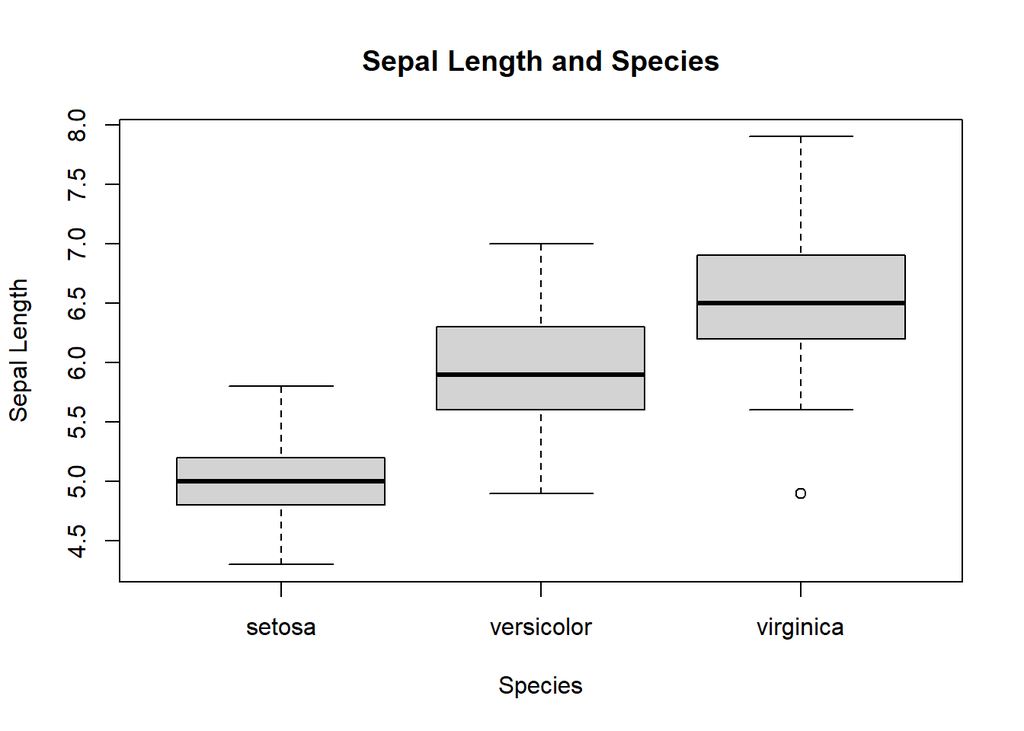

```r
boxplot(
    Sepal.Length ~ Species, data = iris,
    main = "Sepal Length and Species",
    ylab = "Sepal Length",
    xlab = "Species")
```

#Q5 (1 pt.): Conduct a normality test on the residuals of the species/sepal length model and report the p-value. Do the residuals meet the assumption of normality, how do you know? Hint: check out the residuals() and shapiro.test() functions.

```r
iris$residuals <- residuals(fit_species)

shapiro.test(iris$residuals)
```

```
##
##  Shapiro-Wilk normality test
##
## data:  iris$residuals
## W = 0.9879, p-value = 0.2189
```

```r
#The p-value is 0.2189. This high p-value means that we do not have evidence to reject the null hypothesis of normally distributed residuals. The residuals for this model meet the assumption of normality for this general linear model.
```

```r
bartlett.test(Sepal.Length ~ Species,
    data = iris)
```

```
##
##  Bartlett test of homogeneity of variances
##
## data:  Sepal.Length by Species
## Bartlett's K-squared = 16.006, df = 2, p-value = 0.0003345
```

#Q6 (1 pt.): Given your boxplot and the results of your normality test, do you conclude that a linear model is appropriate? Why or why not? # The linear model seems appropriate given the results of the normality test, since these data meet the assumption of normally distributed residuals. However, from looking at the boxplot I am concerned that these data might not meet the constant variance assumption. It looks like the Setosa species has less variation than the other two species. I ran a Bartlett test of homogeniety of variances, and the low p-value indicates that we have evidence to reject the null hypothesis of homogeniety of variance. I think we might need to consider a data transformation or some other method to address this issue.

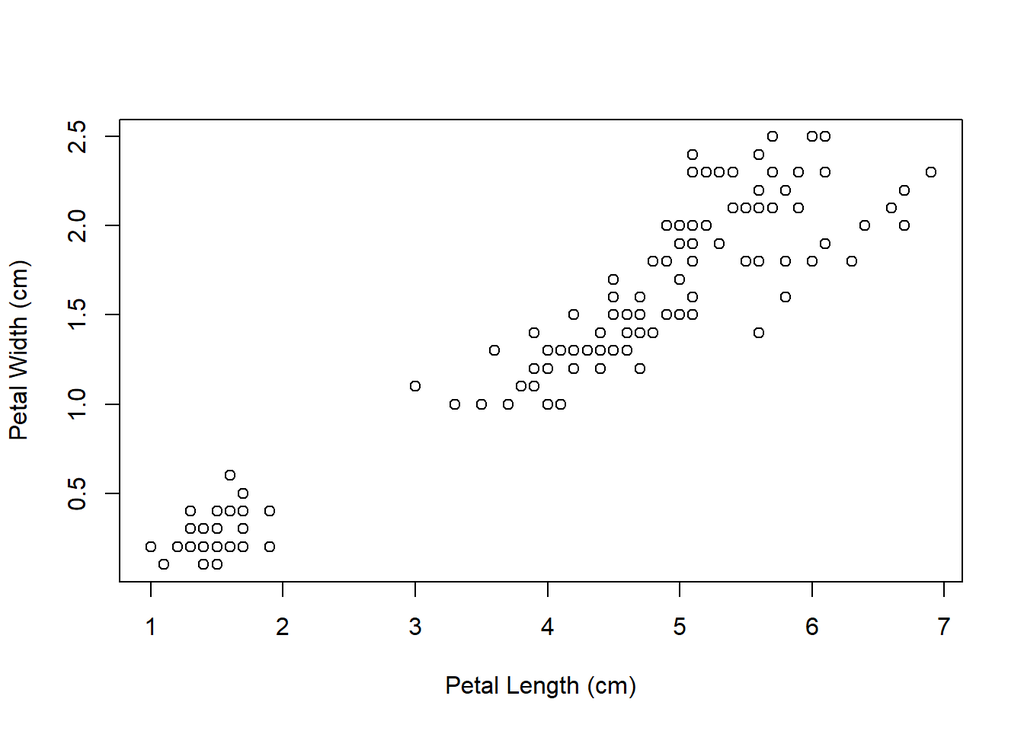

```r
#Model Coefficients with Continuous Predictor
plot(
  Petal.Width ~ Petal.Length,
  data = iris,
  xlab = "Petal Length (cm)",
  ylab = "Petal Width (cm)")
```

```r
fit_petals =
  lm(
    Petal.Width ~ Petal.Length,
    data = iris)

summary(fit_petals)
```

```
##
## Call:
## lm(formula = Petal.Width ~ Petal.Length, data = iris)
##
## Residuals:
##      Min       1Q   Median       3Q      Max
## -0.56515 -0.12358 -0.01898  0.13288  0.64272
##
## Coefficients:
##               Estimate Std. Error t value Pr(>|t|)
## (Intercept)  -0.363076   0.039762  -9.131  4.7e-16 ***
## Petal.Length  0.415755   0.009582  43.387  < 2e-16 ***
## ---
## Signif. codes:  0 '***' 0.001 '**' 0.01 '*' 0.05 '.' 0.1 ' ' 1
##
## Residual standard error: 0.2065 on 148 degrees of freedom
## Multiple R-squared:  0.9271, Adjusted R-squared:  0.9266
## F-statistic:  1882 on 1 and 148 DF,  p-value: < 2.2e-16
```

#Questions about Continuous Predictor Model Coefficients

#Q7 (1 pt.): What is the expected width of a petal of length 0cm? Show your calculation. #Intercept = -0.363076 #Slope = 0.415755 #Expected width of petal length of 0 cm = -0.363076 + 0.415755(0) = -0.363076

#Q8 (1 pt.): What is the expected width of a petal of length 4cm? Show your calculation.

#Expected width of petal length of 4 cm = -0.363076 + 0.415755(4) = 1.299944

#Q9 (1 pt.): Does the model meet the assumption of normality of the residuals? How do you know?

```r
iris$residuals_p <- residuals(fit_petals)

shapiro.test(iris$residuals_p)
```

```
##
##  Shapiro-Wilk normality test
##
## data:  iris$residuals_p
## W = 0.98378, p-value = 0.07504
```

```r
#The p-value is 0.07504. This high p-value means that we do not have evidence to reject the null hypothesis of normally distributed residuals. The residuals for this model meet the assumption of normality for this general linear model.
```